# Zero waste 책을 읽고 나서 느낀 소감

안녕하세요, 코윈 환지팀 ( 환경을 지키는 팀)에 소속된 이 금하 입니다.

처음에는 호기심 반, 이게 가능한 일인가 싶어 책을 구입하게 되었습니다. 그리고 제가 코윈 환지팀에서 활동하기 시작하면서 이 책의 내용을 코윈 회원들과 같이 나누고 싶은 욕심이 생겼습니다. 사실 남 앞에서 무언가를 전달한다는게 내가 실천을 해야만 다른 사람들에게도 내 이야기를 효과적으로 나눌수 있겠다 싶어, 큰 포부와 희망을 가지고 이책을 읽기 시작했습니다. 하지만 주부의 삶에 있어 책 내는 시간,짬을 내는게 쉽지는 않았던것 같습니다. 더군다나 집중해서 읽어야 할것 같아서 더 쉽지 않았던것 같습니다. 그래도 이 책을 통해 얻을 잇점들을 생각하면서 끝까지 읽으려고 했습니다.

우선 이 책의 제목에서 알수 있듯이 쓰레기를 0 으로 만들려고 한다는것을 알수 있습니다. 사실 환경을 위해 실천할수 있는 방안들이 많이 있겠지만 제일 손 쉽게 할수 있는게 집에서 하는 것들이 아닌가 싶습니다. 그래서 이 작가의 간단한 소개와 함께 이 작가가 저희에게 전달하려는 핵심을 소개하면서 마지막으로 저희 개인이 할수 있는 zero waste 행동들에 대해 이야기 해 볼까 합니다.

# 작가의 성장 배경

처음에 이 작가는 왜 환경에 대해 생각을 바꾸게 되었는지 이야기 했습니다. 프랑스에서 태어나고 자라 미국사람과 결혼, 한 가족을 만들면서( 남자 아이 둘), 우리가 흔히 말하는 선망의 집- 큰 차, 차고 3대, 모든것들로 채워져 있는 집이였고 남편도 회사에서 잘 나가는, 남 부러울것 없이 살았는데, 살면서 뭔가가 맞지 않다는 느낌을 가지게 되었습니다. 그때 나이, 32살. 삶은 무기력 했고(sedentary), 차 없이는 쉽게 다닐수 없는 환경이였습니다. 그래서 모든곳들을 쉽게 걸어서 갈수 있는 활동적인 유럽 스타일의 시내(downtown)로 이사를 갔는데 집이 아주 작았다고 합니다. 아마 강남 같이 비싼 곳이 아니였나 싶습니다.

# 5Rs and the benefits of the zero waste lifestyle ( 작가가 전달하려는 핵심)

## Zero waste가 무엇일까요?

이 5개 단계들을 따른다면 쓰레기 줄이기가 간단하게 됩니다.

#### 1. 거절하기(refuse)

필요하지 않는것 거절하기

#### 2. 줄이기 (reduce)

필요한것들 줄이기

#### 3. 다시 사용하기( reuse)

우리가 쓰는것들을 다시 쓰기

#### 4. 재 활용하기(recycle)

거절, 줄이기, 다시 사용할수 없는것들은 재활용

#### 5. 썩히기 (rot)

나머지는 거름( compost) 으로 만들기

## 첫번째 단계 : 거절하기

#### 1. 한번쓰고 버리는 일회용 플라스틱: 비닐봉지, 컵, 뚜껑, 빨대, 일회용 접시..

그런데 이 용품들은 유독한 산업과정을 포함하기에 몸에 해로운 화학물질로 만들어지고, 그것들이 땅, 음식, 몸 속으로 스며들어갑니다. 그리고 그 물질들이 쉽게 재활용되지 않고 분해되지도 않을것입니다( not biodegradable). 이 생산물들은 또한 바다 오염의 원인이기도 합니다. 그리고 그 물질들은 도시 외각 도로옆, 길 옆, 공원, 숲에서도 매일 보입니다. 조금의 계획과 다시 쓰기로 피할수 있습니다.

#### 2. 공짜물건들(Freebies): 호텔파티, 행사 등등에서 주는 아이템들

이 물건들은 집을 더 어지렵히고 정리하기 더 힘들고 이것들을 거절하는데는 강한 의지가 필요합니다.

#### 3. 잡동사니 우편물(junk mail)

이것들을 만들어내기까지 소중한 자원들을 씁니다( deforestation). 분명히 시간과 돈의 낭비입니다.

#### 4. 지속가능하지 않는 관행들

- 하나씩 포장된 스낵들, 지나치게 포장된 제품들
- 종이 영수증보다 이메일, 텍스트등으로 받아보기
- 특히 선물을 받을 경우 거절하기 힘들지만, 공손하게 거절하기. 보통사람들은 개인적 결정을 존중하고 이해 할수 있을겁니다.

## 두번째 단계: 줄이기 (reduce)

#### 1. 과거 소비 평가하기

- 항상 가지고 있어야 한다는 것들을 포기하는데 도전해보기( salad spinner)
- 집에 있는 모든것에 의문을 가져보면 많은 발견들을 만들것입니다. ( 집에 있는 물건들을 기부, 파는것 또한 지역사회나 중고 가게를 돕는 겁니다.
- 이 과정은 새로운 물건이 집에 오기전 두번 생각하게 합니다.
- 쓰레기 영으로 하는데 도움을 줍니다.

적게 가지고 있으면 그로 인한 걱정, 청소, 유지, 고치고 없애는 것들을 적게 만듭니다.

#### 2. 현재 쓰는 것들의 양, 크기 줄이기

- 포장 줄이기( 대량으로 사기)
- 차 사용( 자전거 더 타기)
- 집 크기( 집 크기 줄이기)
- 종이 사용(이것을 프린트 해야 하나?)
- technology(이것 없이 할수 있나?)
- 더 적은 양 사용( 농축된 양)

#### 3. 소비로 이끄는 활동들 줄이기

- 미디어 노출(TV, 잡지)
- 즐기는 쇼핑(leisure shopping)
- 뭔가 시대에 뒤 처지는 느낌

그러다 보면 사고 싶은 유혹에 빠집니다, 그래서 우리가 가진것에 만족하려고 노력합니다.

#### Comfort level ( 자기가 편할수 있는 정도에서..)

예를 들어 대중 교통이 없는 시골에 사는 사람들에게 차 사용은 없앨수 없습니다. 하지만 차 한대 아니면 운전 덜하기, 강조하는것은 현 소비습관을 인식하고 지속가능하지 않는것( unsustainable)들은 줄이는 방법을 찾도록 하는것입니다.

## 세번째 단계: 다시 사용하기( reuse)

#### 1. 낭비적 소비를 없애기

- 쇼핑시 재활용한것들을 가지고 다니기( 크고 작은 병,컨테이너, 크고 작은 천 가방)

#### 2. 중고 제품들 사기

#### 3. 현명하게 사기

다시 쓸수 있고( refillable), 다시 충전할수 있고(rechargeable), 다시 고칠수 있고(repairable), 다양한 용도로 쓸수 있고(versatile), 오래 쓸수 있는 용품들 사기

#### 4. 쓸수 있는 기간 늘리기

- 수리(repairing)- 철물가게 가거나 제조 업체에 전화해 문제 해결하기
- 다시 생각( rethinking)- 먹는 컵이 볼펜통으로 만들기
- 돌려주기(returning)- 드라이 클리닝 옷걸이 다시 쓸수 있게 가게에 되돌려 주기
- 구조하기(rescuing)- 한면만 쓴 종이는 재활용 전 다시 쓰기, 닳아진 옷은 매립장 가기전 행주나 걸레로 쓰기

## 네번째 단계: 재활용

- 다시 쓰기, 줄이기가 되지 않는것들은 재활용 하기

## 다섯번째 단계: 썩히기 (rot)

유기물질(organic material) 의 재활용으로 거름 만들기- composting

Zero waste 라이프 스타일의 잇점들

#### 1. 재정/ 금전

- 소비( 물건 사는것) 줄이기
- 보관 장소, 수리 비용 줄이기
- 대량으로 사면 더 싸다
- 쓰레기 봉투 사용 줄이기
- 양 보다는 질을 선택
- 안쓰는 물건 팔면서 이익 남기기남기기

#### 2. 건강

- 플라스틱 제품 포장은 안사도록 하면서 음식으로 들어 갈수 있는 유해 물질(BPA) 걱정을 줄일수 있음
- 자연 요법,청소 제품등에 있어 잘 모르는 화학물질 노출 줄이기
- 덜 가지고 살면 먼지 쌓이는것도 줄이고 그 먼지들이 알레르기를 동반하는데 그것들을 줄일수 있음
- 야외 활동 격려: 비타민 D 손실에 효과, 더 신선한 공기 제공, 육체적 활동 증가시킴
- 정제된 음식을 줄이고 whole food사는것 장려
- 선전, 광고 노출을 줄이다 보면 건강하지 않는 음식에 대한 갈망 줄임
- 고기 소비 줄임

#### 3. 시간

- 다시 쓰는것은 쇼핑하고 물건 버리고 하는 그 모든 시간을 절약
- 나누고 서로 연결되면서 지역사회 연대감을 강화시킴
- 집단 소비 참여 기회 제공, 같은 마음을 가진 사람들 발견하고 미래에 대해 더 많은 희망을 가질수 있음
- 더 늘어난 시간에 내가 좋아하는것, 그것들은 생각하는 사람들과 시간을 갖는 더 값진 삶을 줄것입니다.
- 지식, 현명함,, 자신감, 열정

# 집안에서 zero waste에 도전

## 첫번째 장소: 부엌

```
환경위기를 평가하고 우리 삶에서 모든것들과 연결고리를 찾는데 결국 기본으로 돌아가는게 해결책입니다
```

인터넷, social media로 인해 “ homemaking” 에 대한 서로간의 지식 공유, 협력하는 기본을 제공합니다. 사실 버터 만들고 치즈 만들고 하는 그런 과정이 얼마나 힘든지 결국 이런것들을 만드는 시간, 재정적 제한들에 대해 조심해야 합니다. 이런 만드는 과정이 장기적인 zero waste plan 에 대한 부분이 아닙니다. 쉽게 그리고 환경을 생각하는 유지가능한(sustainable) 균형을 찾는것입니다.

#### 부엌 설치(set up)

- 어떻게 쇼핑하나?(how to shop)
- 어떻게 식단을 계획하나?(how to plan meals)

zero waste 삶은 어느정도 homemaking을 포함합니다. 간소화 (simplicity), 효율성( efficiency)가 핵심요소입니다. 예를 들어 와플기계나 소벳만드는 기구등은 정말로 쓰는지- 부엌에 쓰는 소품들이 더 적을수록 음식준비도 더 빠르게 됩니다. 한번 정도, 모든것을 꺼내놓고 꼭 필요한것들만 다시 씁니다.

#### 1. 작동이 되는가?

지금 고치던지, 팔던지, 기부한다, 아니면 버린다(예를 들어 유통기간이 지난 음식은 거름으로 만들기)

#### 2. 정기적으로 사용하나?

내가 지난달에 썼는지? 아니면 기부한다.

#### 3. 여분(duplicate)이 있나?

예를 들어 제일 좋아하는 오븐 장갑을 고른다.

#### 4. 이것이 가족 건강에 해롭나?

테플론(Teflon), 코팅이 된 제품들, 알루미늄, 플라스틱은 건강에 해롭다. 그래서 버리는게 낫다. 플라스틱 주걱, 국자는 재활용하고 나무나, 철((metal)제품들은 유지한다.

#### 5. 죄책감(guilt)에 유지하나?

누가 선물로 주었는데 당신이 필요없다면 없애는것도 괜찮다.

#### 6. 모든 사람이 가지고 있어서 가지고 있는건가?

정말 필요한지 평가 해보기(Egg slicer, salad spinner)

#### 7. 시간을 들여 청소할 만큼 가치가 있나?

장식용품들( 내가 이 장소를 다른 무언가를 위해 사용할수 있나? 그리고 빈 공간 여부의 공간을 숨쉴수 있는 공간을 마련에 준다

#### 8. 다시 사용할수 있나?

만약 아니라면 다른 사람이 사용할수 있나? 버리는것을 두려워 하지 말고 덜 가짐으로써 얻을수 있는 이익에 집중한다.

## 재사용 가능 (reusability)

#### 1. 금속(metal), 유리, 종이가 기본인 제품들을 고르고 플라스틱은 피한다

#### 2. 키친타올(paper towel) 대신 오래된 천 사용

#### counter 선반, 손 닦는 행주로 사용

#### 3. 물병 - 스텐레스(stainless) 병

- 개인당 하나씩, 아이들은 두개(보온이 되는 병 포함)
- 플라스틱 병에 있는 물은 낭비적이고 수도물만큼 규제되지 않아서 무엇을 마시는지 잘 모른다.

#### 4. 샌드위치나 냉동백— 조그만 병들 수집( 여러가지 크기)

얼리고, 저장 음식 운반에 사용, 그리고 남은 음식을 위해서도 사용

#### 5. 종이 냅킨: 천 냅킨 을 사용 ( 손님들 위해 30개 정도)

#### 6. 티백- 거름망(strainer) 사용

## 식료품 쇼핑(grocery shopping)

#### 1. 식료품과 기타 목록들

목록을 적는것은 시간과 돈 절약을 하는데 도움을 준다

#### 2. 음식 쓰레기 줄이기

#### 3. Bulk vs Bulk

건강식품 가게(health food store)에서 대량(bulk)으로 사는게 때로는 큰 소매가게(big warehouse, club)에서 대량으로 사는게 오히려 돈 절감을 가져올수 있다. 특히 준비된 음식(prepared foods)등의 소비를 줄인다면 더 많은 식자재 비용을 줄일수 있다. 사실 질좋은 음식이 싸지는 않지만 장기간으로 보면 환경과 우리 건강에 대한 투자하고 볼수 있다. 그리고 식사 제품 뿐 아니라 포장되지 않는 물건들 모두를( 비누나 청소용품들) 대량 구매하는것도 포함한다. 그래서 식료품 가게뿐만 아니라 farmer’s market 도 포장이 안된 제품들을 살수 있는 원천이 된다.

## 욕실 설정(bathroom set up)

### 단순화

건강, 위생, 몸단장을 하는데 기본적 기능 제공

서랍장, 캐비넷을 치우면서 정말 필요한것들인지 평가해보고 단순화시키면 평온한 욕실로 만드는 두번째 단계이다

오래된것은 아닌가? - 몇년이 지난 화장품들은 박테리아 증가를 제공하면서 건강에 해로움

내가 정기적으로 사용하나? - 만약 적어도 한달에 한번 사용하지 않고 먼지만 쌓이면 버린다.

여분이 있나?

가족 건강에 해가 되나? - 욕실제품들에 쓰이는 화학성분들이 건강에 문제를 야기시킬수 있다.

죄의식?- 다른사람들이 돈을 써서 선물로 주었는데..

다른 사람들이 모두 가지고 있어 가지고 있는지.. 예를 들면 입청결제(mouthwash, Q-tips)

내 소중한 시간에 먼지 닦고 깨끗이 할 가치가 있는것인지. 습기, 먼지는 좋은 친구들이 아닙니다. 만약 장식 용품들이 욕실에 있다면 먼지 닦기가 쉽지 않습니다.

내가 이 공간을 다른것을 위해 사용할수 있는지. 머리 말기 같은 것들은 많은 공간을 차지합니다. 그래서 다시 한번 생각해 보기.

다시 사용할수 있는지? - 일회용품(일회용 면도기)은 더 이상 구매하지 않고 대신 다시 쓸수 있는 포장이 안된 용품들을 고른다( 마른 제품들은 천가방, 물기 있는 제품들은 병을 이용해 쇼핑을 한다)

### 몸단장과 위생

#### bar( 덩어리)

```
    손, 몸, 얼굴에 쓰는 비누들
```

#### 액체 상태 bulk

```
    Castile 비누
```

#### 로션- bulk lotion, bulk oil( 요리할때 쓰는 기름들)

```
          인조 합성 성분들이 있는지 살펴보기
```

## 침실과 옷장(bedroom, wardrobe)

#### Minimalist (간단하게 말하면 줄이기- simply reduce!)

단순화 하기- 잠자기, 책읽기, 옷갈아 입기에 관련되지 않는것들은 버리기

입기 좋은 상태인가? 오래 되었나? 구멍이 나거나 찢어지거나 얼룩이 다시 쓸수 있는지, 불가능한 경우 걸레나 행주로 쓸수 있다.

정기적으로 입는가?

똑 같은것이 또 있는가? 특이 액세서리(스카프)

#### 가족의 건강에 해롭나?

```
나일론, 폴리에스테르, 아크릴 등의 소재는 피부 알레르기를 야기시킬수 있다
```

죄의식때문에 가지고 있나?

사회적인 눈때문에 가지고 있나? – 모든 사람이 가지고 있어서?

## 식초의 마법

물한컵, 정제된 흰색 식초1/4컵을 스프레이 병에 채우기

접착성있는것 제거

욕실 청소: 기본믹스를 카운터, 바닥 싱크대에 사용, 거울, 비누때, 얼룩등을 치솔에 기본믹스를 사용하여 청소

색깔: 만약 옷빨때 피가 묻었으면 빨기전 식초물에 담그기

살충제(insect repellent) 개미가 들어오는 곳에 스프레이 뿌리기

부엌 청소제: 도마 살균, 전자렌지는 식초 뿌리고 베이킹 소다를 살짝 뿌리고 밤새 나누고 나서 청소,

음식병에서 나는 불쾌한 냄새 없애는데도 식초 사용

세탁 강화( 부스터): ½ 컵 식초를 헹구기 할때 넣으면 비누 쌓이는 것과 색이 노랗게 되는것 방지, 섬유 유연제, 색깔 강화, 마찰 생기는것을 줄일수 있다.

곰팡이 제거와 방지

애완동물 방충제 (pet repellent)- 강아지나 고양이가 실수 할수 있거나 스크래치, 씹으려 하는것들에 효과

빠른 물청소

얼룩 제거제: 크레용, 연필, 겨자 같은 데 식초를 부어 치솔로 비벼 얼룩제거 한 다음 빨래한다.

화장실 청소: 더 확실한 청소를 하고 싶을때는 식초, 베이킹 소다를 뿌리고 잠시 둔 다음 청소하기

가구류 닦기: 헝겊에 묻혀 닦기

## 작가가 이 책을 마무리하면서 우리에게 상기시키는 것들…

이 작가가 책을 마무리하는데 독자들에게 다시 한번 zero waste의 목적과 바램을 상기시키고 있습니다. Zero waste는 쓰레기 줄이는것에 한정되지 않고 소박한 기쁨을 즐기고 우리가 사는 지역의 로컬, 제철 음식을 먹으며 더 건강한 삶을 살고 더 많은 야외 활동을 즐기고 지역사회에 더 참여하고 삶을 단순화하면서 정말 중요한것들에 자리를 만드는것입니다. 물질적 욕구에서 벗어나 내적 성장으로 대처 될수 있는 사회를 상상해 보세요.. 우리가 덜 쓰면 일이 더 줄어들고 더 풍요롭게 살것입니다!

## 이 책을 읽고 나서 바라는 저의 작은 바램..

저의 작은 바램이 책을 읽고 나서 다시 한번 환경 문제에 대한 인식뿐만 아닌 행동으로 옮길수 있는 많은 예들을 개인적이기도 하지만 코윈활동을 통해 서로서로 환경보호를 위한 행동들을 같이 나누고 지지, 격려할수 있는 기회를 만들려고 합니다. 제가 요약한 내용들을 5월달에 읽고 나서 5월말에 zero waste challenge 를 만들어서 그것을 6월동안 실천해보는것은 어떨가 싶습니다. 실천사항으로 여기 나온 예들뿐 아니라 전부터 환경보호를 위해 꼭 한번 실천해보고 싶었던 것들도 괜찮지 않을까 싶네요. 그리고 챌린지를 개인이 각자 만들어서 그게 하나이든, 여러개이든 그것은 코윈회원님들이 정하시고 6월말 정도 다시 야외에서 만나 그동안 챌린지 활동이 어떠했는지 이야기 나누는것도 좋을것 같습니다.

### Challenge 이벤트

##### zero waste challenge

###### 5월달 매주 이책을 내용별로 나누어서 코윈 웹싸이트에 올릴것 입니다.

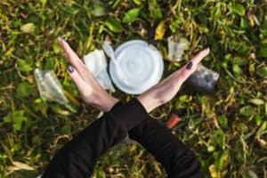

**5월 첫째주**: 이 작가의 성장 배경 과 전달하려는 핵심요약 읽기

**5월 둘째주:** 집안 다른 장소에서 zero waste 방법에 대한 핵심요약 읽기

**5월 셋째 주:** 식초의 마법과 이책의 마무리 요약 읽기

**5월 넷째 주:** zero waste challenge 만들어서 같이 공유하기( 이 메일을 통해서)

6월동안 zero waste challenge를 실천하고 6월 셋째 주 정도 야외에서 한번 만나서 서로의 챌린지 성공여부 나누기( 여기에 대한 더 자세한 내용은 6월초에 다시 말씀드리도록 하겠습니다)